# Proj1 Lyrics HW

Qichao Chen

2019/9/16

```r
## get the dataframe
mydata<-read.csv("C:/Users/beca9/OneDrive/Desktop/5243/proj1/doc/dt_lyrics.csv")
table(mydata$genre)
```

```
##
##       Country    Electronic          Folk       Hip-Hop         Indie
##          7534          2812           514          8905          1318
##          Jazz         Metal Not Available         Other           Pop
##          4122         11311          3325           147         18697
##           R&B          Rock
##          2174         64845
```

## General picture: How do people feel when they listen music?

The Lyrics classifies all songs into 12 categories: *Rock*, *Pop*, *Metal*, *Hip-Hop*, *Country*, *Jazz*, *Not Available*, *Electronic*, *R&B*, *Indie*, *Folk* and *Other*. In order to get a general sense of 12 categories play, a frequency distribution analysis and setiment analysis will be performed in this part.

### Frequency distribution of the 12 categories

Among the 12 categories, I’m wondering how the frequencies are distributed. In other words, which category appears with most times and which is the least.

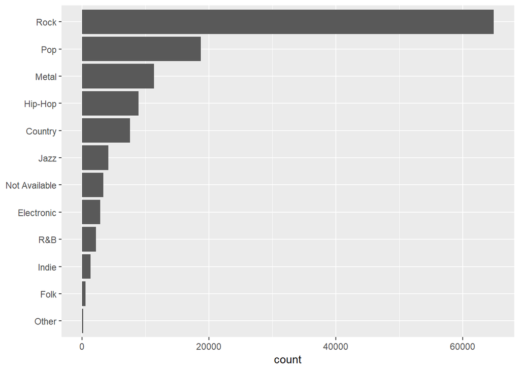

The ranking shows that *Rock*, *Pop* and *Metal* are top 3 categories of songs which means that these 3 kinds of songs are most popular.